# Project: Create a Data Structure to hold Voter Information

Using the data structures and algorithms we have covered so far, you will implement a custom data structure for managing and analyzing voter data. It will be roughly analagous to a Pandas DataFrame (but you won't need to implement all the functionality that are provided by DataFrames!)

The basic functionality of your data structure can be demonstrated using the Pandas dataframe. In the cell below:

- Some synthetic voter data is generated
- The data is collected in a Pandas DataFrame, where each voter is stored as a single row.

```python
from synthetic_data import *
import pandas as pd

# generate synthetic voter data
data = generate_dataset(n=10)
print(data)
# collect voters as rows
df = pd.DataFrame(data)

display(df)
```

```
[{'voter_id': 6419868424, 'age': 27, 'county': 'Gwinnett', 'party': 'Republican', 'income_bracket': '50-100K', 't_2016': 1, 't_2018': 0, 't_2020': 1, 't_2022': 1}, {'voter_id': 3190339672, 'age': 71, 'county': 'DeKalb', 'party': 'Republican', 'income_bracket': '<50K', 't_2016': 1, 't_2018': 1, 't_20…
```

|  | voter_id | age | county | party | income_bracket | t_2016 | t_2018 | t_2020 | t_2022 |
| --- | --- | --- | --- | --- | --- | --- | --- | --- | --- |
| 0 | 6419868424 | 27 | Gwinnett | Republican | 50-100K | 1 | 0 | 1 | 1 |
| 1 | 3190339672 | 71 | DeKalb | Republican | <50K | 1 | 1 | 1 | 1 |
| 2 | 5072431329 | 78 | Cobb | Democrat | <50K | 1 | 1 | 1 | 1 |
| 3 | 2455533081 | 37 | Fulton | Democrat | <50K | 0 | 0 | 1 | 0 |
| 4 | 6655955162 | 24 | Clayton | Independent | <50K | 0 | 1 | 1 | 0 |
| 5 | 5995163933 | 64 | Clayton | Independent | 50-100K | 0 | 1 | 1 | 0 |
| 6 | 8474701654 | 42 | Fulton | Democrat | <50K | 1 | 1 | 1 | 0 |
| 7 | 2480944757 | 64 | Cobb | Independent | 50-100K | 1 | 1 | 0 | 1 |
| 8 | 2686265566 | 53 | Gwinnett | Republican | 50-100K | 0 | 0 | 1 | 1 |
| 9 | 1882648921 | 83 | Clayton | Republican | 50-100K | 1 | 1 | 1 | 1 |

```python
data[1]
```

```
{'voter_id': 3190339672,
 'age': 71,
 'county': 'DeKalb',
 'party': 'Republican',
 'income_bracket': '<50K',
 't_2016': 1,
 't_2018': 1,
 't_2020': 1,
 't_2022': 1}
```

- After creating the DataFrame, we may get new data, which can be added to the DataFrame.

```python
# generate new data
new_data = generate_dataset(n=2)

# add it to the DataFrame as new rows
df = pd.concat([df, pd.DataFrame(new_data)], ignore_index=True)

display(df)
```

|  | voter_id | age | county | party | income_bracket | t_2016 | t_2018 | t_2020 | t_2022 |
| --- | --- | --- | --- | --- | --- | --- | --- | --- | --- |
| 0 | 6419868424 | 27 | Gwinnett | Republican | 50-100K | 1 | 0 | 1 | 1 |
| 1 | 3190339672 | 71 | DeKalb | Republican | <50K | 1 | 1 | 1 | 1 |
| 2 | 5072431329 | 78 | Cobb | Democrat | <50K | 1 | 1 | 1 | 1 |
| 3 | 2455533081 | 37 | Fulton | Democrat | <50K | 0 | 0 | 1 | 0 |
| 4 | 6655955162 | 24 | Clayton | Independent | <50K | 0 | 1 | 1 | 0 |
| 5 | 5995163933 | 64 | Clayton | Independent | 50-100K | 0 | 1 | 1 | 0 |
| 6 | 8474701654 | 42 | Fulton | Democrat | <50K | 1 | 1 | 1 | 0 |
| 7 | 2480944757 | 64 | Cobb | Independent | 50-100K | 1 | 1 | 0 | 1 |
| 8 | 2686265566 | 53 | Gwinnett | Republican | 50-100K | 0 | 0 | 1 | 1 |
| 9 | 1882648921 | 83 | Clayton | Republican | 50-100K | 1 | 1 | 1 | 1 |
| 10 | 5891204569 | 61 | Fulton | Democrat | >100K | 0 | 1 | 1 | 1 |
| 11 | 8826743898 | 54 | Cobb | Democrat | <50K | 1 | 1 | 0 | 1 |

- We can sort the rows of the DataFrame by any of the columns:

```python
df.sort_values(by = "voter_id",inplace=True)
display(df)
print()
df.sort_values(by = "county",inplace=True)
display(df)

# ...or any of these other variables
df.sort_values(by = "age", inplace=True)
# df.sort_values(by="party",inplace=True)
# df.sort_values(by="income_bracket",inplace=True)
display(df)
# df.sort_values(by="t_2016",inplace=True)
# df.sort_values(by="t_2018",inplace=True)
# df.sort_values(by="t_2020",inplace=True)
# df.sort_values(by="t_2022",inplace=True)
```

|  | voter_id | age | county | party | income_bracket | t_2016 | t_2018 | t_2020 | t_2022 |
| --- | --- | --- | --- | --- | --- | --- | --- | --- | --- |
| 9 | 1882648921 | 83 | Clayton | Republican | 50-100K | 1 | 1 | 1 | 1 |
| 3 | 2455533081 | 37 | Fulton | Democrat | <50K | 0 | 0 | 1 | 0 |
| 7 | 2480944757 | 64 | Cobb | Independent | 50-100K | 1 | 1 | 0 | 1 |
| 8 | 2686265566 | 53 | Gwinnett | Republican | 50-100K | 0 | 0 | 1 | 1 |
| 1 | 3190339672 | 71 | DeKalb | Republican | <50K | 1 | 1 | 1 | 1 |
| 2 | 5072431329 | 78 | Cobb | Democrat | <50K | 1 | 1 | 1 | 1 |
| 10 | 5891204569 | 61 | Fulton | Democrat | >100K | 0 | 1 | 1 | 1 |
| 5 | 5995163933 | 64 | Clayton | Independent | 50-100K | 0 | 1 | 1 | 0 |
| 0 | 6419868424 | 27 | Gwinnett | Republican | 50-100K | 1 | 0 | 1 | 1 |
| 4 | 6655955162 | 24 | Clayton | Independent | <50K | 0 | 1 | 1 | 0 |
| 6 | 8474701654 | 42 | Fulton | Democrat | <50K | 1 | 1 | 1 | 0 |
| 11 | 8826743898 | 54 | Cobb | Democrat | <50K | 1 | 1 | 0 | 1 |

|  | voter_id | age | county | party | income_bracket | t_2016 | t_2018 | t_2020 | t_2022 |
| --- | --- | --- | --- | --- | --- | --- | --- | --- | --- |
| 9 | 1882648921 | 83 | Clayton | Republican | 50-100K | 1 | 1 | 1 | 1 |
| 5 | 5995163933 | 64 | Clayton | Independent | 50-100K | 0 | 1 | 1 | 0 |
| 4 | 6655955162 | 24 | Clayton | Independent | <50K | 0 | 1 | 1 | 0 |
| 7 | 2480944757 | 64 | Cobb | Independent | 50-100K | 1 | 1 | 0 | 1 |
| 2 | 5072431329 | 78 | Cobb | Democrat | <50K | 1 | 1 | 1 | 1 |
| 11 | 8826743898 | 54 | Cobb | Democrat | <50K | 1 | 1 | 0 | 1 |
| 1 | 3190339672 | 71 | DeKalb | Republican | <50K | 1 | 1 | 1 | 1 |
| 3 | 2455533081 | 37 | Fulton | Democrat | <50K | 0 | 0 | 1 | 0 |
| 10 | 5891204569 | 61 | Fulton | Democrat | >100K | 0 | 1 | 1 | 1 |
| 6 | 8474701654 | 42 | Fulton | Democrat | <50K | 1 | 1 | 1 | 0 |
| 8 | 2686265566 | 53 | Gwinnett | Republican | 50-100K | 0 | 0 | 1 | 1 |
| 0 | 6419868424 | 27 | Gwinnett | Republican | 50-100K | 1 | 0 | 1 | 1 |

|  | voter_id | age | county | party | income_bracket | t_2016 | t_2018 | t_2020 | t_2022 |
| --- | --- | --- | --- | --- | --- | --- | --- | --- | --- |
| 4 | 6655955162 | 24 | Clayton | Independent | <50K | 0 | 1 | 1 | 0 |
| 0 | 6419868424 | 27 | Gwinnett | Republican | 50-100K | 1 | 0 | 1 | 1 |
| 3 | 2455533081 | 37 | Fulton | Democrat | <50K | 0 | 0 | 1 | 0 |
| 6 | 8474701654 | 42 | Fulton | Democrat | <50K | 1 | 1 | 1 | 0 |
| 8 | 2686265566 | 53 | Gwinnett | Republican | 50-100K | 0 | 0 | 1 | 1 |
| 11 | 8826743898 | 54 | Cobb | Democrat | <50K | 1 | 1 | 0 | 1 |
| 10 | 5891204569 | 61 | Fulton | Democrat | >100K | 0 | 1 | 1 | 1 |
| 5 | 5995163933 | 64 | Clayton | Independent | 50-100K | 0 | 1 | 1 | 0 |
| 7 | 2480944757 | 64 | Cobb | Independent | 50-100K | 1 | 1 | 0 | 1 |
| 1 | 3190339672 | 71 | DeKalb | Republican | <50K | 1 | 1 | 1 | 1 |
| 2 | 5072431329 | 78 | Cobb | Democrat | <50K | 1 | 1 | 1 | 1 |
| 9 | 1882648921 | 83 | Clayton | Republican | 50-100K | 1 | 1 | 1 | 1 |

- Even after sorting, we may receive new data. After adding this to the DataFrame, we need to re-sort.

```python
# generate new data
new_data = generate_dataset(n=7)

df = pd.concat([df, pd.DataFrame(new_data)], ignore_index=True)
display(df)
print()
df.sort_values(by = "age",inplace=True)
display(df)
```

|  | voter_id | age | county | party | income_bracket | t_2016 | t_2018 | t_2020 | t_2022 |
| --- | --- | --- | --- | --- | --- | --- | --- | --- | --- |
| 0 | 6655955162 | 24 | Clayton | Independent | <50K | 0 | 1 | 1 | 0 |
| 1 | 6419868424 | 27 | Gwinnett | Republican | 50-100K | 1 | 0 | 1 | 1 |
| 2 | 2455533081 | 37 | Fulton | Democrat | <50K | 0 | 0 | 1 | 0 |
| 3 | 8474701654 | 42 | Fulton | Democrat | <50K | 1 | 1 | 1 | 0 |
| 4 | 2686265566 | 53 | Gwinnett | Republican | 50-100K | 0 | 0 | 1 | 1 |
| 5 | 8826743898 | 54 | Cobb | Democrat | <50K | 1 | 1 | 0 | 1 |
| 6 | 5891204569 | 61 | Fulton | Democrat | >100K | 0 | 1 | 1 | 1 |
| 7 | 5995163933 | 64 | Clayton | Independent | 50-100K | 0 | 1 | 1 | 0 |
| 8 | 2480944757 | 64 | Cobb | Independent | 50-100K | 1 | 1 | 0 | 1 |
| 9 | 3190339672 | 71 | DeKalb | Republican | <50K | 1 | 1 | 1 | 1 |
| 10 | 5072431329 | 78 | Cobb | Democrat | <50K | 1 | 1 | 1 | 1 |
| 11 | 1882648921 | 83 | Clayton | Republican | 50-100K | 1 | 1 | 1 | 1 |
| 12 | 2292603583 | 86 | DeKalb | Republican | >100K | 1 | 1 | 1 | 1 |
| 13 | 3345350944 | 24 | Cobb | Democrat | 50-100K | 0 | 0 | 0 | 1 |
| 14 | 3824893769 | 54 | Gwinnett | Republican | <50K | 1 | 1 | 1 | 1 |
| 15 | 2656977684 | 85 | Gwinnett | Independent | <50K | 1 | 1 | 1 | 1 |
| 16 | 7772305214 | 28 | Fulton | Republican | <50K | 1 | 1 | 0 | 1 |
| 17 | 3385456352 | 22 | Gwinnett | Independent | <50K | 1 | 1 | 1 | 1 |
| 18 | 1580258830 | 36 | Clayton | Republican | 50-100K | 1 | 0 | 0 | 1 |

|  | voter_id | age | county | party | income_bracket | t_2016 | t_2018 | t_2020 | t_2022 |
| --- | --- | --- | --- | --- | --- | --- | --- | --- | --- |
| 17 | 3385456352 | 22 | Gwinnett | Independent | <50K | 1 | 1 | 1 | 1 |
| 0 | 6655955162 | 24 | Clayton | Independent | <50K | 0 | 1 | 1 | 0 |
| 13 | 3345350944 | 24 | Cobb | Democrat | 50-100K | 0 | 0 | 0 | 1 |
| 1 | 6419868424 | 27 | Gwinnett | Republican | 50-100K | 1 | 0 | 1 | 1 |
| 16 | 7772305214 | 28 | Fulton | Republican | <50K | 1 | 1 | 0 | 1 |
| 18 | 1580258830 | 36 | Clayton | Republican | 50-100K | 1 | 0 | 0 | 1 |
| 2 | 2455533081 | 37 | Fulton | Democrat | <50K | 0 | 0 | 1 | 0 |
| 3 | 8474701654 | 42 | Fulton | Democrat | <50K | 1 | 1 | 1 | 0 |
| 4 | 2686265566 | 53 | Gwinnett | Republican | 50-100K | 0 | 0 | 1 | 1 |
| 14 | 3824893769 | 54 | Gwinnett | Republican | <50K | 1 | 1 | 1 | 1 |
| 5 | 8826743898 | 54 | Cobb | Democrat | <50K | 1 | 1 | 0 | 1 |
| 6 | 5891204569 | 61 | Fulton | Democrat | >100K | 0 | 1 | 1 | 1 |
| 7 | 5995163933 | 64 | Clayton | Independent | 50-100K | 0 | 1 | 1 | 0 |
| 8 | 2480944757 | 64 | Cobb | Independent | 50-100K | 1 | 1 | 0 | 1 |
| 9 | 3190339672 | 71 | DeKalb | Republican | <50K | 1 | 1 | 1 | 1 |
| 10 | 5072431329 | 78 | Cobb | Democrat | <50K | 1 | 1 | 1 | 1 |
| 11 | 1882648921 | 83 | Clayton | Republican | 50-100K | 1 | 1 | 1 | 1 |
| 15 | 2656977684 | 85 | Gwinnett | Independent | <50K | 1 | 1 | 1 | 1 |
| 12 | 2292603583 | 86 | DeKalb | Republican | >100K | 1 | 1 | 1 | 1 |

- We can sort by a value that does not explicitly appear as a column, but is defined by the data in each row:

```python
# create temporary column
df["turnout_rate"] = df[["t_2016", "t_2018", "t_2020", "t_2022"]].sum(axis = 1) / 4

# sort by the temporary column
df.sort_values(by="turnout_rate",inplace=True)

# drop the temporary column
df.drop(columns="turnout_rate",inplace=True)
df
```

|  | voter_id | age | county | party | income_bracket | t_2016 | t_2018 | t_2020 | t_2022 |
| --- | --- | --- | --- | --- | --- | --- | --- | --- | --- |
| 13 | 3345350944 | 24 | Cobb | Democrat | 50-100K | 0 | 0 | 0 | 1 |
| 2 | 2455533081 | 37 | Fulton | Democrat | <50K | 0 | 0 | 1 | 0 |
| 0 | 6655955162 | 24 | Clayton | Independent | <50K | 0 | 1 | 1 | 0 |
| 18 | 1580258830 | 36 | Clayton | Republican | 50-100K | 1 | 0 | 0 | 1 |
| 4 | 2686265566 | 53 | Gwinnett | Republican | 50-100K | 0 | 0 | 1 | 1 |
| 7 | 5995163933 | 64 | Clayton | Independent | 50-100K | 0 | 1 | 1 | 0 |
| 1 | 6419868424 | 27 | Gwinnett | Republican | 50-100K | 1 | 0 | 1 | 1 |
| 16 | 7772305214 | 28 | Fulton | Republican | <50K | 1 | 1 | 0 | 1 |
| 3 | 8474701654 | 42 | Fulton | Democrat | <50K | 1 | 1 | 1 | 0 |
| 5 | 8826743898 | 54 | Cobb | Democrat | <50K | 1 | 1 | 0 | 1 |
| 6 | 5891204569 | 61 | Fulton | Democrat | >100K | 0 | 1 | 1 | 1 |
| 8 | 2480944757 | 64 | Cobb | Independent | 50-100K | 1 | 1 | 0 | 1 |
| 17 | 3385456352 | 22 | Gwinnett | Independent | <50K | 1 | 1 | 1 | 1 |
| 11 | 1882648921 | 83 | Clayton | Republican | 50-100K | 1 | 1 | 1 | 1 |
| 10 | 5072431329 | 78 | Cobb | Democrat | <50K | 1 | 1 | 1 | 1 |
| 14 | 3824893769 | 54 | Gwinnett | Republican | <50K | 1 | 1 | 1 | 1 |
| 15 | 2656977684 | 85 | Gwinnett | Independent | <50K | 1 | 1 | 1 | 1 |
| 9 | 3190339672 | 71 | DeKalb | Republican | <50K | 1 | 1 | 1 | 1 |
| 12 | 2292603583 | 86 | DeKalb | Republican | >100K | 1 | 1 | 1 | 1 |

- We can search for items in the DataFrame based on some condition:

```python
# indices corresponding to voters older than 30
print("Indices corresponding to voters older than 30:")
print(df[df["age"] > 30].index.to_list())
print()
print("Indices corresponding to Fulton county voters:")
print(df[df["county"] == "Fulton"].index.to_list())
```

```
Indices corresponding to voters older than 30:
[2, 18, 4, 7, 3, 5, 6, 8, 11, 10, 14, 15, 9, 12]

Indices corresponding to Fulton county voters:
[2, 16, 3, 6]
```

# Your Task

- Instead of storing the data as rows in a Pandas DataFrame, you will implement your own data structure, a *VoterRegistry* class.
- Instead of storing data in rows, a VoterRegistry stores multiple Voter objects, which is implemented in the next cell.

```python
class Voter:
    def __init__(self, voter_id, age, county, party, income_bracket, turnout_history):
        self.voter_id = voter_id
        self.age = age
        self.county = county
        self.party = party
        self.income_bracket = income_bracket
        self.turnout_history = turnout_history  # list of 0/1

    def turnout_rate(self):
        if not self.turnout_history:
            return 0.0
        return sum(self.turnout_history) / len(self.turnout_history)

    def __repr__(self):
        return (
            f"Voter(id={self.voter_id}, age={self.age}, "
            f"county='{self.county}', party='{self.party}', "
            f"income='{self.income_bracket}')"
        )

# Example use for one data point from a generated dataset
data = generate_dataset(n=100)
single_data_pt = data[0]
turn_out = [single_data_pt["t_2016"], single_data_pt["t_2018"],
    single_data_pt["t_2020"], single_data_pt["t_2022"]]

voter = Voter(single_data_pt["voter_id"],
            single_data_pt["age"],
            single_data_pt["county"],
            single_data_pt["party"],
            single_data_pt["income_bracket"],
            turn_out)

print(voter)
print(voter.turnout_rate())
```

```
Voter(id=2976729328, age=83, county='DeKalb', party='Republican', income='>100K')
0.75
```

- Your VoterRegistry structure must store the Voter objects as either:
  - A collection of linked Nodes. (You may make any edits to the Node class you deem necessary).
  - A Hash Table. For simplicity, you are allowed to use Python lists here, but the index location must be determined by a hash function.
- If you choose to implement a Hash Table, keep the following in mind:
  - We want to be able to add additional Voter objects when new data is generated, so the length of the Python list may need to be dynamically adjusted.
  - To resolve hash collisions, you can use rehashing or you can try chaining using a linked Node structure.
  - We can't "sort" a Hash Table, but you can sort a **view** of a Hash Table (a temporary contiguous array).
- Your VoterRegistry should perform the same basic tasks that we saw with the Pandas DataFrames above:
  - It can be initialized from the output of `generate_dataset`.
  - It can be sorted in ascending order by "voter_id", "age", "county", "party", "income_bracket" and the turnout for the years 2016, 2018, 2020, 2022.
  - It can be sorted in ascending order by the turnout rate. Note that this isn't an attribute of a Voter object, but can be calculated using the `turnout_rate` method.
  - New voter data can be added/appended to the VoterRegistry.
  - We can search for indices/locations corresponding to conditions based on the Voter attributes and standard Boolean comparison operators.
- Perform benchmarking, testing your searching and sorting methods. Try varying the size of the stored data and whether the data is already "almost" sorted or sorted in the opposite order. Summarize your results.
- To make your code and write-up as readable as possible, please include Markdown text describing your implementation decisions and what each object/method/function does.

# Rubric

1. **Data Structure Design & Implementation (4 points)**: Correctly implements the required data structure (e.g., linked list or hash table), with well-defined classes and attributes that support all require voter fields.
2. **Data Addition & Storage (4 points)**: Successfully adds new voter records, maintains data integrity, and supports dynamic updates (e.g., appending and re-sorting)
3. **Sorting Functionality (4 points)**: Correctly sorts by any required "column" (attribute) and by the computed value of turnout rate.
4. **Search Functionality (3 points)**: Implements search by voter attributes and supports Boolean conditions.
5. **Testing, Demonstration, & Benchmarking (3 points)**: Demonstrates all features with clearly shown examples (e.g., different dataset sizes, re-sorting after additions) and includes benchmarking or performance discussion.
6. **Code Quality & Documentation (2 points)**: Code is clean, readable, well-organized, and clearly documented with Markdown explanations of design decisions.

### Data Structure: Linked List

`VoterRegistry` stores `Voter` objects as a single-linked list of `VoterNode` objects. This design mimics the `Node` class and the linked-list traversal pattern: a `_head` pointer and a `current = current.next` loop.

`VoterNode` is a simplified version of that `Node`, here we store `Voter` objects directly.

### Sorting: Merge Sort

Sorting uses merge sort, extended with a `key` parameter (like Python's built-in `sorted`). Merge sort was chosen because:

- O(n log n) worst case: unlike quicksort, performance is consistent regardless of initial order (random, sorted, reversed).
- Stable: equal-keyed elements preserve their original relative order.

Workflow: extract all `Voter` objects to a Python list -> merge sort with the chosen key -> rebuild the linked list in sorted order.

`income_bracket` needs a custom numeric mapping (`"<50K"-> 0`, `"50-100K"-> 1`, `">100K"-> 2`) because its natural order is not alphabetical.

### Searching: Linear Scan

`search(condition)` traverses every node once, collecting 0-based indices where `condition(voter)` is `True`. This is O(n): the same asymptotic cost as any unsorted sequential structure.

### Benchmarking

Timing uses `timeit.default_timer` and log-log plots.

```python
# VoterNode:
# Stores a Voter object; the primitive-only restriction from the original Node is removed.

class VoterNode:
    """A node in the VoterRegistry linked list. Holds one Voter object."""

    def __init__(self, voter):
        self._data = voter
        self._next = None

    def get_data(self):
        return self._data
    def set_data(self, voter):
        self._data = voter
    data = property(get_data, set_data)

    def get_next(self):
        return self._next
    def set_next(self, node_next):
        self._next = node_next
    next = property(get_next, set_next)

    def __repr__(self):
        return f"VoterNode({self._data})"


# income_bracket strings do not sort in their natural order alphabetically
# ('<' < '5' < '>'), so we map each bracket to an integer rank.
INCOME_ORDER = {"<50K": 0, "50-100K": 1, ">100K": 2}

# Maps each sortable attribute name to a function that extracts the
# comparison value from a Voter object.
SORT_KEYS = {
    "voter_id":       lambda v: v.voter_id,
    "age":            lambda v: v.age,
    "county":         lambda v: v.county,
    "party":          lambda v: v.party,
    "income_bracket": lambda v: INCOME_ORDER[v.income_bracket],
    "t_2016":         lambda v: v.turnout_history[0],
    "t_2018":         lambda v: v.turnout_history[1],
    "t_2020":         lambda v: v.turnout_history[2],
    "t_2022":         lambda v: v.turnout_history[3],
    "turnout_rate":   lambda v: v.turnout_rate(),
}
```

```python
# Merge sort, extended with a 'key' parameter so any voter attribute
# (or computed value) can drive the comparison.

def merge_sort(a_list, key=lambda x: x):
    """
    Sort a_list in-place in ascending order using merge sort.
    key: function extracting the comparison value from each element.
    Complexity: O(n log n) worst case. Stable.
    """
    if len(a_list) <= 1:
        return

    mid = len(a_list) // 2
    left_half = a_list[:mid]
    right_half = a_list[mid:]

    merge_sort(left_half, key)
    merge_sort(right_half, key)

    i, j, k = 0, 0, 0
    while i < len(left_half) and j < len(right_half):
        if key(left_half[i]) <= key(right_half[j]):
            a_list[k] = left_half[i]
            i += 1
        else:
            a_list[k] = right_half[j]
            j += 1
        k += 1

    while i < len(left_half):
        a_list[k] = left_half[i]
        i += 1
        k += 1

    while j < len(right_half):
        a_list[k] = right_half[j]
        j += 1
        k += 1
```

```python
class VoterRegistry:
    """
    Linked-list data structure for storing and managing Voter objects.

    Supports:
    - Initialization from generate_dataset() output
    - Appending new voter records
    - Sorting in ascending order by any voter attribute (or turnout_rate)
    - Searching by Boolean conditions on voter attributes
    """

    def __init__(self, data):
        """
        Build the registry from the list of dicts returned by generate_dataset().
        Each dict is converted to a Voter object and appended to the linked list.
        """
        self._head = None
        self._tail = None
        self._size = 0
        for record in data:
            self._append_voter(self._dict_to_voter(record))

    # internal helpers

    def _dict_to_voter(self, d):
        """Convert a generate_dataset dict to a Voter object."""
        return Voter(
            d["voter_id"], d["age"], d["county"], d["party"],
            d["income_bracket"],
            [d["t_2016"], d["t_2018"], d["t_2020"], d["t_2022"]]
        )

    def _append_voter(self, voter):
        """Append a Voter object to the tail of the linked list."""
        new_node = VoterNode(voter)
        if self._head is None:
            self._head = new_node
            self._tail = new_node
        else:
            self._tail.next = new_node
            self._tail = new_node
        self._size += 1

    def _rebuild_from_list(self, voter_list):
        """Replace linked list contents with a Python list of Voter objects."""
        self._head = None
        self._tail = None
        self._size = 0
        for voter in voter_list:
            self._append_voter(voter)

    # public interface

    def to_list(self):
        """Traverse the linked list and return all Voter objects as a Python list."""
        result = []
        current = self._head
        while current is not None:
            result.append(current.data)
            current = current.next
        return result

    def append(self, new_data):
        """
        Add new voter records to the registry.
        Accepts a single dict or a list of dicts (from generate_dataset).
        The registry is not automatically re-sorted; call sort() afterwards if needed.
        """
        if isinstance(new_data, dict):
            new_data = [new_data]
        for record in new_data:
            self._append_voter(self._dict_to_voter(record))

    def sort(self, by="voter_id"):
        """
        Sort the registry in ascending order by the given attribute.
        Valid keys: voter_id, age, county, party, income_bracket,
                    t_2016, t_2018, t_2020, t_2022, turnout_rate.
        Uses merge sort: O(n log n), stable.
        """
        if by not in SORT_KEYS:
            raise ValueError(
                f"Unknown sort key '{by}'. Choose from: {list(SORT_KEYS.keys())}"
            )
        voters = self.to_list()
        merge_sort(voters, key=SORT_KEYS[by])
        self._rebuild_from_list(voters)

    def search(self, condition):
        """
        Return 0-based indices of voters satisfying condition.
        condition: callable (Voter -> bool).

        Examples:
            registry.search(lambda v: v.age > 30)
            registry.search(lambda v: v.county == "Fulton")
            registry.search(lambda v: v.party == "Democrat" and v.turnout_rate() == 1.0)
        """
        indices = []
        current = self._head
        idx = 0
        while current is not None:
            if condition(current.data):
                indices.append(idx)
            current = current.next
            idx += 1
        return indices

    def __len__(self):
        return self._size

    def __repr__(self):
        voters = self.to_list()
        n_show = min(5, self._size)
        lines = [f"VoterRegistry ({self._size} voters):"]
        for i in range(n_show):
            lines.append(f"  [{i}] {voters[i]}")
        if self._size > n_show:
            lines.append(f"  ... ({self._size - n_show} more)")
        return "\n".join(lines)
```

## Demonstration

```python
# Initialize a VoterRegistry from 100 randomly generated voters
data_100 = generate_dataset(n=100)
registry = VoterRegistry(data_100)

print(registry)
```

```
VoterRegistry (100 voters):
  [0] Voter(id=4505612678, age=40, county='Gwinnett', party='Democrat', income='>100K')
  [1] Voter(id=9935344746, age=60, county='Gwinnett', party='Republican', income='>100K')
  [2] Voter(id=4632020275, age=76, county='DeKalb', party='Independent', income='>100K')
  [3] Voter(id=2488712363, age=22, county='Gwinnett', party='Democrat', income='>100K')
  [4] Voter(id=4028241840, age=71, county='Clayton', party='Democrat', income='50-100K')
  ... (95 more)
```

```python
# Sort by age
registry.sort(by="age")
voters = registry.to_list()
print("Sorted by age (first 5):")
for i, v in enumerate(voters[:5]):
    print(f"  [{i}] age={v.age:3d}  {v}")

print()

# Sort by county
registry.sort(by="county")
voters = registry.to_list()
print("Sorted by county (first 5):")
for i, v in enumerate(voters[:5]):
    print(f"  [{i}] county={v.county:10s}  {v}")

print()

# Sort by income_bracket
# Uses custom numeric mapping: <50K -> 0, 50-100K -> 1, >100K -> 2
registry.sort(by="income_bracket")
voters = registry.to_list()
print("Sorted by income_bracket (first 5):")
for i, v in enumerate(voters[:5]):
    print(f"  [{i}] income={v.income_bracket:10s}  {v}")

print()

#  Sort by turnout_rate
registry.sort(by="turnout_rate")
voters = registry.to_list()
print("Sorted by turnout_rate (first 5):")
for i, v in enumerate(voters[:5]):
    print(f"  [{i}] turnout_rate={v.turnout_rate():.2f}  {v}")
```

```
Sorted by age (first 5):
  [0] age= 19  Voter(id=4969662747, age=19, county='Gwinnett', party='Republican', income='50-100K')
  [1] age= 19  Voter(id=6531926747, age=19, county='Gwinnett', party='Democrat', income='50-100K')
  [2] age= 20  Voter(id=8433416326, age=20, county='Gwinnett', party='Democrat', income='50-100K')
  [3] age= 21  Voter(id=6422613970, age=21, county='Gwinnett', party='Democrat', income='<50K')
  [4] age= 22  Voter(id=2488712363, age=22, county='Gwinnett', party='Democrat', income='>100K')

Sorted by county (first 5):
  [0] county=Clayton     Voter(id=7689480862, age=24, county='Clayton', party='Republican', income='<50K')
  [1] county=Clayton     Voter(id=1713421429, age=30, county='Clayton', party='Democrat', income='>100K')
  [2] county=Clayton     Voter(id=1556655607, age=30, county='Clayton', party='Republican', income='<50K')
  [3] county=Clayton     Voter(id=6396089042, age=31, county='Clayton', party='Democrat', income='>100K')
  [4] county=Clayton     Voter(id=5344791623, age=31, county='Clayton', party='Democrat', income='>100K')

Sorted by income_bracket (first 5):
  [0] income=<50K        Voter(id=7689480862, age=24, county='Clayton', party='Republican', income='<50K')
  [1] income=<50K        Voter(id=1556655607, age=30, county='Clayton', party='Republican', income='<50K')
  [2] income=<50K        Voter(id=9725412468, age=59, county='Clayton', party='Independent', income='<50K')
  [3] income=<50K        Voter(id=9572520543, age=60, county='Clayton', party='Republican', income='<50K')
  [4] income=<50K        Voter(id=6761799426, age=68, county='Clayton', party='Republican', income='<50K')

Sorted by turnout_rate (first 5):
  [0] turnout_rate=0.00  Voter(id=4969662747, age=19, county='Gwinnett', party='Republican', income='50-100K')
  [1] turnout_rate=0.25  Voter(id=7011420876, age=35, county='DeKalb', party='Republican', income='<50K')
  [2] turnout_rate=0.25  Voter(id=6422613970, age=21, county='Gwinnett', party='Democrat', income='<50K')
  [3] turnout_rate=0.25  Voter(id=6526821420, age=31, county='DeKalb', party='Democrat', income='50-100K')
  [4] turnout_rate=0.25  Voter(id=4898390983, age=28, county='Fulton', party='Republican', income='50-100K')
```

```python
print(f"Registry size before append: {len(registry)}")

# Generate and append 10 new voter records
new_data = generate_dataset(n=10)
registry.append(new_data)

print(f"Registry size after append:  {len(registry)}")

# New records land at the tail unsorted — re-sort to restore order
registry.sort(by="age")
voters = registry.to_list()

print("After appending 10 voters and re-sorting by age (first 5):")
for i, v in enumerate(voters[:5]):
    print(f"  [{i}] age={v.age:3d}  {v}")

print("Last 5 (oldest voters):")
for i, v in enumerate(voters[-5:], start=len(voters) - 5):
    print(f"  [{i}] age={v.age:3d}  {v}")
```

```
Registry size before append: 100
Registry size after append:  110
After appending 10 voters and re-sorting by age (first 5):
  [0] age= 19  Voter(id=4969662747, age=19, county='Gwinnett', party='Republican', income='50-100K')
  [1] age= 19  Voter(id=6531926747, age=19, county='Gwinnett', party='Democrat', income='50-100K')
  [2] age= 19  Voter(id=1142239079, age=19, county='Clayton', party='Independent', income='<50K')
  [3] age= 20  Voter(id=8433416326, age=20, county='Gwinnett', party='Democrat', income='50-100K')
  [4] age= 20  Voter(id=9246424793, age=20, county='Cobb', party='Democrat', income='50-100K')
Last 5 (oldest voters):
  [105] age= 88  Voter(id=1300606347, age=88, county='Gwinnett', party='Independent', income='<50K')
  [106] age= 88  Voter(id=9336187219, age=88, county='DeKalb', party='Republican', income='50-100K')
  [107] age= 88  Voter(id=1610865051, age=88, county='Fulton', party='Democrat', income='>100K')
  [108] age= 90  Voter(id=6187916958, age=90, county='Cobb', party='Democrat', income='>100K')
  [109] age= 90  Voter(id=9437298802, age=90, county='Fulton', party='Republican', income='<50K')
```

```python
# Reset to voter_id order so indices are stable and meaningful
registry.sort(by="voter_id")

# Voters older than 60
idx_old = registry.search(lambda v: v.age > 60)
print(f"Voters with age > 60 — count: {len(idx_old)}")
print("  Indices:", idx_old[:10])

print()

# Fulton county voters
idx_fulton = registry.search(lambda v: v.county == "Fulton")
print(f"Fulton county voters — count: {len(idx_fulton)}")
print("  Indices:", idx_fulton[:10] )

print()

# Democrats with 100% turnout rate
idx_loyal = registry.search(lambda v: v.party == "Democrat" and v.turnout_rate() == 1.0)
print(f"Democrats with 100% turnout — count: {len(idx_loyal)}")
print("  Indices:", idx_loyal[:10], )

print()

# Retrieve and display one matched voter
all_voters = registry.to_list()
if idx_fulton:
    v = all_voters[idx_fulton[0]]
    print(f"First Fulton voter (index {idx_fulton[0]}): {v}")
```

```
Voters with age > 60 — count: 50
  Indices: [2, 3, 4, 6, 8, 10, 12, 13, 14, 15]

Fulton county voters — count: 25
  Indices: [2, 8, 11, 13, 18, 22, 23, 30, 37, 38]

Democrats with 100% turnout — count: 25
  Indices: [2, 5, 8, 10, 15, 16, 18, 24, 26, 29]

First Fulton voter (index 2): Voter(id=1231093004, age=84, county='Fulton', party='Democrat', income='<50K')
```

## Benchmarking

We time `sort()` across different dataset sizes and initial orderings, and `search()` across sizes. Timing uses `timeit.default_timer`, results are plotted on a log-log scale.

Expected behavior:

- `sort`: O(n log n). Merge sort always splits and merges every level regardless of initial order, so timing should be similar for random, pre-sorted, and reversed input.
- `search`: O(n). Linear scan —> time grows proportionally to n.

```python
from timeit import default_timer
import matplotlib.pyplot as plt
import numpy as np


def time_sort(n, order="random", by="age", repeats=5):
    """
    Time VoterRegistry.sort() on a dataset of size n.
    order: 'random', 'sorted', or 'reversed'
    Returns average time in seconds over `repeats` independent runs.
    Each run re-generates the data so the initial state is always fresh.
    """
    times = []
    for _ in range(repeats):
        reg = VoterRegistry(generate_dataset(n=n))
        if order == "sorted":
            reg.sort(by=by)
        elif order == "reversed":
            reg.sort(by=by)
            voters = reg.to_list()
            voters.reverse()
            reg._rebuild_from_list(voters)
        start = default_timer()
        reg.sort(by=by)
        times.append(default_timer() - start)
    return sum(times) / repeats


def time_search(n, repeats=5):
    """
    Time VoterRegistry.search() on a dataset of size n.
    Returns average time in seconds over `repeats` independent runs.
    """
    times = []
    for _ in range(repeats):
        reg = VoterRegistry(generate_dataset(n=n))
        start = default_timer()
        _ = reg.search(lambda v: v.age > 40)
        times.append(default_timer() - start)
    return sum(times) / repeats
```

```python
sizes = [100, 500, 1000, 2000, 5000]

print("Sort timing by dataset size (random order)")
sort_times_random = []
for n in sizes:
    t = time_sort(n, order="random")
    sort_times_random.append(t)
    print(f"  n={n:5d}: {t*1000:.3f} ms")

print()
print("Sort timing by initial ordering (all sizes)")
ordering_times = {"random": [], "sorted": [], "reversed": []}
for n in sizes:
    for order in ["random", "sorted", "reversed"]:
        t = time_sort(n, order=order)
        ordering_times[order].append(t)
    print(f"  n={n:5d}  random={ordering_times['random'][-1]*1000:.2f}ms  "
          f"sorted={ordering_times['sorted'][-1]*1000:.2f}ms  "
          f"reversed={ordering_times['reversed'][-1]*1000:.2f}ms")

print()
print("Search timing by dataset size")
search_times = []
for n in sizes:
    t = time_search(n)
    search_times.append(t)
    print(f"  n={n:5d}: {t*1000:.3f} ms")
```

[output not shown]

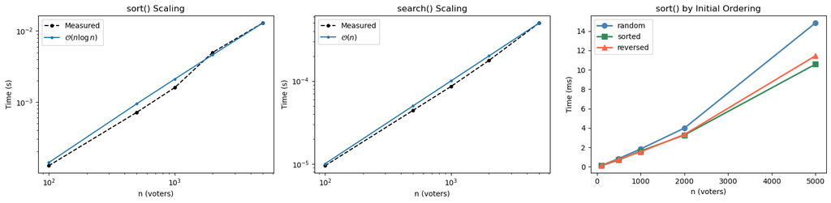

```python
n_arr = np.array(sizes)
sort_arr = np.array(sort_times_random)
search_arr = np.array(search_times)

fig, axes = plt.subplots(1, 3, figsize=(16, 4))

# Plot 1: Sort scaling
ax = axes[0]
nlogn = n_arr * np.log(n_arr)
C = sort_arr[-1] / nlogn[-1]
ax.loglog(n_arr, sort_arr, 'k.--', label="Measured", markersize=8)
ax.loglog(n_arr, C * nlogn, '.-', label=r"$\mathcal{O}(n \log n)$", markersize=6)
ax.set_xlabel("n (voters)")
ax.set_ylabel("Time (s)")
ax.set_title("sort() Scaling")
ax.legend()

# Plot 2: Search scaling
ax = axes[1]
C2 = search_arr[-1] / n_arr[-1]
ax.loglog(n_arr, search_arr, 'k.--', label="Measured", markersize=8)
ax.loglog(n_arr, C2 * n_arr, '.-', label=r"$\mathcal{O}(n)$", markersize=6)
ax.set_xlabel("n (voters)")
ax.set_ylabel("Time (s)")
ax.set_title("search() Scaling")
ax.legend()

# Plot 3: Initial ordering effect
ax = axes[2]
styles = {"random": ("steelblue", "o"), "sorted": ("seagreen", "s"), "reversed": ("tomato", "^")}
for order, (color, marker) in styles.items():
    t_ms = np.array(ordering_times[order]) * 1000
    ax.plot(sizes, t_ms, marker=marker, color=color,
            label=order, linewidth=2, markersize=7)
ax.set_xlabel("n (voters)")
ax.set_ylabel("Time (ms)")
ax.set_title("sort() by Initial Ordering")
ax.legend()

plt.tight_layout()
plt.show()
```

**Key observation:** The three ordering curves (random, sorted, reversed) closely overlap across most dataset sizes. This is expected, merge sort always divides the list in half and merges every level regardless of what order the data starts in, so initial ordering does not affect the number of operations. Any visible differences in the timing are assumed to be due to system noise rather than algorithmic behavior.

This contrasts with algorithms like insertion sort, which is O(n) on already-sorted data but O(n²) on random or reversed data.